# Final Code

Trelan Hakeem-Barron

4/22/2020

Load data:

# 1)

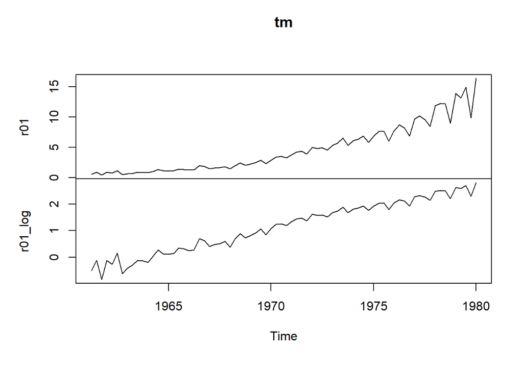

The initial time series is not stationary, since the level of the series increases (does not remain constant in time). The variance of the series also seems to be growing.

For the logarithm of the time series, the variance remains approximately constant in time, but the level of the series increases, which indicates its nonstationarity.

Therefore, the stationary model does not seem reasonable only with a logarithmic transformation.

# 2)

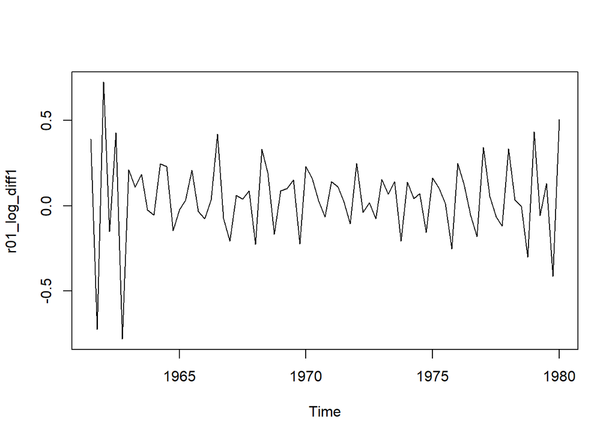

Upon receipt of the first difference of the log time series, it seems stationary, but at the beginning of the series there is something more than normal variability. This is because the series levels start off so small.

# 3)

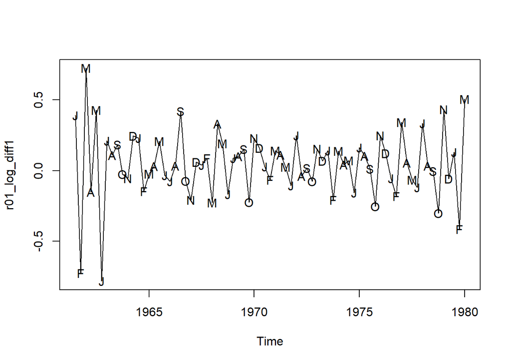

From the above plot, we can conclude that here is the quarterly seasonality (3 months).

# 4)

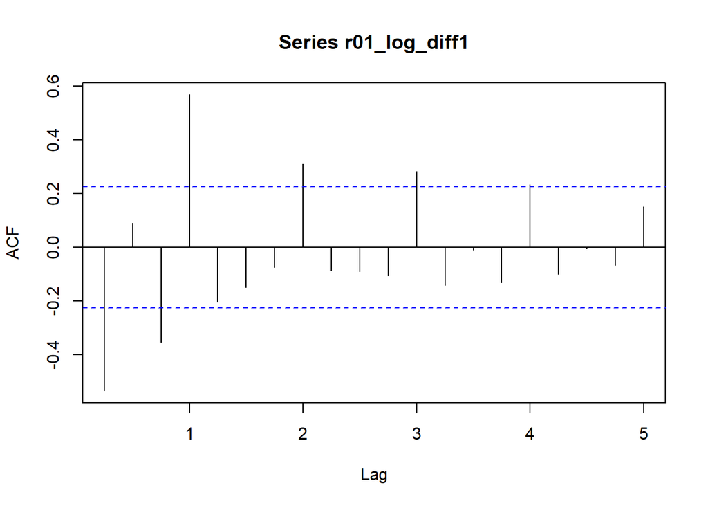

```
##
## Autocorrelations of series 'r01_log_diff1', by lag
##
##   0.25   0.50   0.75   1.00   1.25   1.50   1.75   2.00   2.25   2.50
## -0.534  0.091 -0.354  0.569 -0.203 -0.149 -0.075  0.310 -0.087 -0.090
##   2.75   3.00   3.25   3.50   3.75   4.00   4.25   4.50   4.75   5.00
## -0.107  0.282 -0.141 -0.010 -0.131  0.234 -0.100 -0.004 -0.066  0.151
```

The plot and values of the ACF confirm the assumption of quarterly seasonality. The model has significant lags at 1, 2, 3, and 4.

# 5)

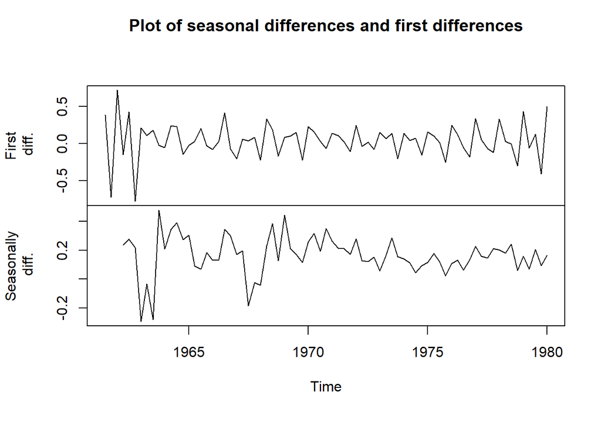

As you can see, only seasonal differences are not enough for the time series to be stationary. The first differences give the best result in understanding stationarity.

# 6)

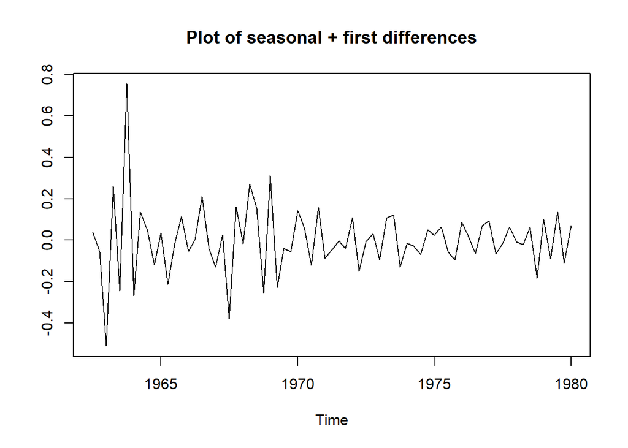

Upon receipt of the first and seasonal difference of the log time series, it seems stationary. At the beginning of the series there is little big than normal variability. This is because the series levels start near zero and we do a logaritm operation.

# 7)

ARIMA-model:

[output not shown]

The p-value of parameters for ARIMA model:

```
##       ma1      sma1
## 0.0000000 0.1510686
```

or by the other way:

```
##
## z test of coefficients:
##
##       Estimate Std. Error  z value Pr(>|z|)
## ma1  -0.769028   0.072737 -10.5727   <2e-16 ***
## sma1  0.163833   0.114108   1.4358   0.1511
## ---
## Signif. codes:  0 '***' 0.001 '**' 0.01 '*' 0.05 '.' 0.1 ' ' 1
```

Thus, the coeficient ma1 is significant (its p-value is less than the significance level $\alpha=0.05$). But the coeficient sma1 is insignificant.

# 8)

Diagnostic Checking:

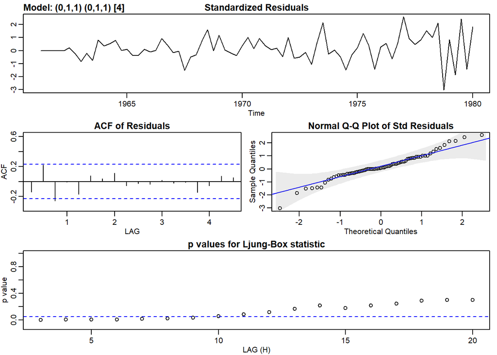

```
## $fit
##
## Call:
## stats::arima(x = xdata, order = c(p, d, q), seasonal = list(order = c(P, D,
##     Q), period = S), include.mean = !no.constant, transform.pars = trans, fixed = fixed,
##     optim.control = list(trace = trc, REPORT = 1, reltol = tol))
##
## Coefficients:
##           ma1    sma1
##       -0.7690  0.1638
## s.e.   0.0727  0.1141
##
## sigma^2 estimated as 0.2128:  log likelihood = -46.26,  aic = 98.53
##
## $degrees_of_freedom
## [1] 69
##
## $ttable
##      Estimate     SE  t.value p.value
## ma1   -0.7690 0.0727 -10.5727  0.0000
## sma1   0.1638 0.1141   1.4358  0.1556
##
## $AIC
## [1] 1.331431
##
## $AICc
## [1] 1.333715
##
## $BIC
## [1] 1.423161
```

# 9)

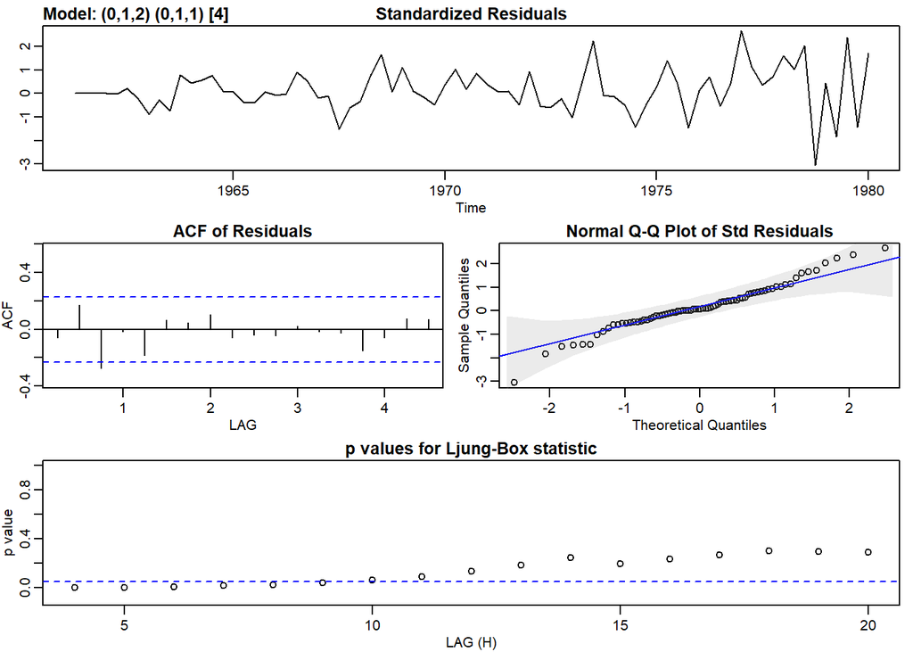

```
## $fit
##
## Call:
## stats::arima(x = xdata, order = c(p, d, q), seasonal = list(order = c(P, D,
##     Q), period = S), include.mean = !no.constant, transform.pars = trans, fixed = fixed,
##     optim.control = list(trace = trc, REPORT = 1, reltol = tol))
##
## Coefficients:
##           ma1     ma2    sma1
##       -0.8395  0.1053  0.0997
## s.e.   0.1109  0.1107  0.1357
##
## sigma^2 estimated as 0.2101:  log likelihood = -45.8,  aic = 99.6
##
## $degrees_of_freedom
## [1] 68
##
## $ttable
##      Estimate     SE t.value p.value
## ma1   -0.8395 0.1109 -7.5691  0.0000
## ma2    0.1053 0.1107  0.9514  0.3448
## sma1   0.0997 0.1357  0.7341  0.4654
##
## $AIC
## [1] 1.345949
##
## $AICc
## [1] 1.350583
##
## $BIC
## [1] 1.468257
```

When we compare these results with those reported in previous paragraph, we see that the estimates of $\theta_1$ and $\theta$ have changed very little—especially when the size of the standard errors is taken into consideration. In addition, the estimate of the new parameter, $\theta_2$, is not statistically different from zero. Note also that the estimate, the log-likelihood, and AIC have not changed much.

# 10)

Forecasts for the next two years of the series:

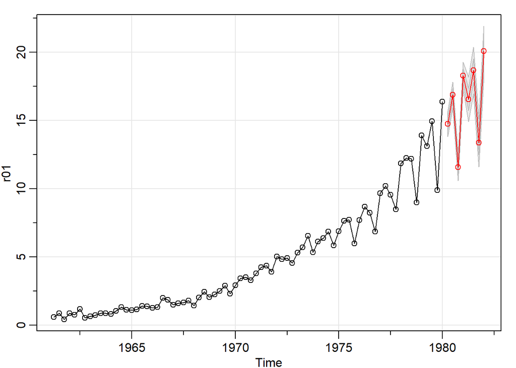

```
## $pred
##          Qtr1     Qtr2     Qtr3     Qtr4
## 1980          14.75459 16.87129 11.57137
## 1981 18.28624 16.55095 18.66765 13.36774
## 1982 20.08260
##
## $se
##           Qtr1      Qtr2      Qtr3      Qtr4
## 1980           0.4613343 0.4734801 0.4853220
## 1981 0.4968817 0.8129863 0.8450493 0.8759394
## 1982 0.9057766
```